# Emotional salience modulates the forward flow of memory

Shield:

[figure not shown]

This work is licensed under a [Creative Commons Attribution-NonCommercial-ShareAlike 4.0 International License](http://creativecommons.org/licenses/by-nc-sa/4.0/).

This repository can be used to reproduce the code from the manuscript Emotional salience modulates the forward flow of memory which can be accessed on PsyArXiv [here](https://osf.io/preprints/psyarxiv/m59nb).

This repository can also be found on OSF [here](https://osf.io/4rbeq/).

# **How is this repository organized?**

Under /Raw_data, you can find the raw data obtained from each participant. Under /Raw_Results you can find the csv and mat files obtained from the /Raw_data that are necessary to reproduce these results which are created with the matlab codes found under /Code.

Lastly, under /Results, you can find the R script stats_figures.Rmd which will load the files from /Raw_Results to reproduce the exact figures needed in this manuscript.

JASP files used for Bayesian analyses can be found in the OSF repository [here](https://osf.io/4rbeq/) under /Results/JASP_files_results.zip

# **How can I get started?**

- v1SOA_preprocessing_alldata.m will output a .mat file called alldata which can then be used to:
  - Calculate overall recall by SOA (list_recall_SOA.m)
- v1SOA_preprocessing_CRP.m will organize the data into 2 matrices used for most of other analyses (emotional_v1_CRP and perceptual_v1_CRP as well as emo_ctrl and per_ctrl). Specifically:
  - The probability of recall (probability_recall.m)
  - CRP analyses (CRP_lag_analyses.m and CRP_lag_abalyses_bySOA.m)

# **Table of contents**

- *Manuscript Figures and Analyses*
- Fig. 1C- Amount of items recalled per SOA
- Fig. 1D- Oddballs vs controls output position
- Fig. 2B Conditional Response Probability Curves
- Fig. 2D- 2E To vs from transitions from oddball items
- *Supplementary Material Figures and Analyses*
- Fig. S1A,S1B,S1C,S1D, Table S1- Recall probability
- Fig. S2 Conditional Response Probability Curves by Stimulus Onset Asynchrony
- Fig. S3- Correlation of lag + 1 from emotional oddballs with E-1 recall
- Output for JASP in table S3, S4, S5- recall probability by SOA (view code)
- Table S6- Emotional ratings
- Table S7- Semantic ratings

# *Manuscript Figures and Analyses*

# Fig. 1C- Amount of items recalled per SOA

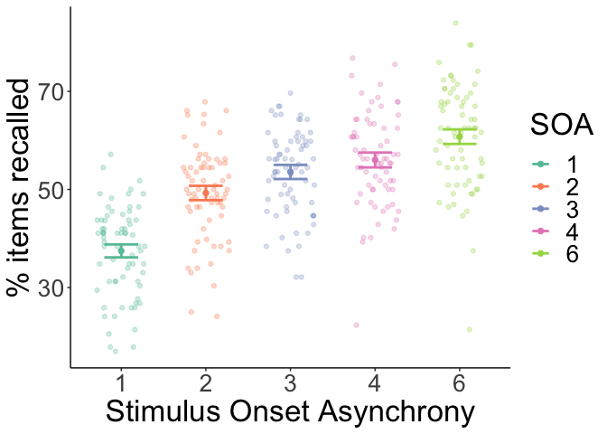

# Fig. 1D- Oddballs vs controls output position

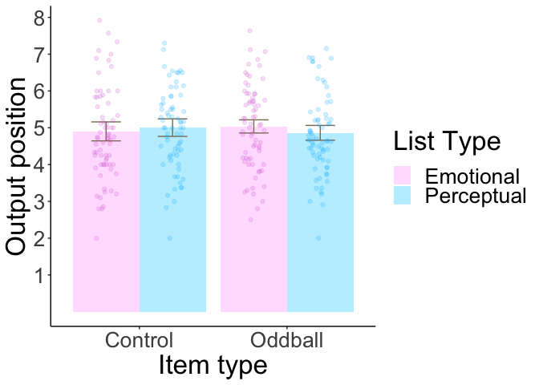

```
## # A tibble: 1 × 4
##     df1   df2 statistic     p
##   <int> <int>     <dbl> <dbl>
## 1     3   275     0.586 0.625

## ANOVA Table (type III tests)
##
##           Effect DFn DFd     F     p p<.05      pes
## 1      list_type   1  68 0.006 0.937       9.21e-05
## 2           item   1  68 0.078 0.780       1.00e-03
## 3 list_type:item   1  68 2.070 0.155       3.00e-02
```

# Fig. 2B Conditional Response Probability Curves

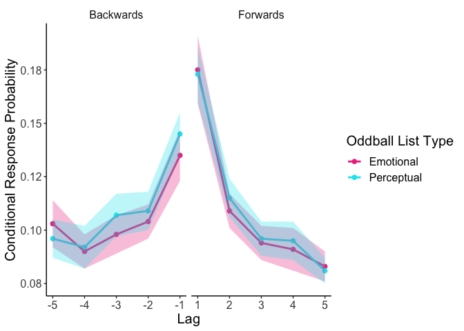

# Fig. 2D- 2E To vs from transitions from oddball items

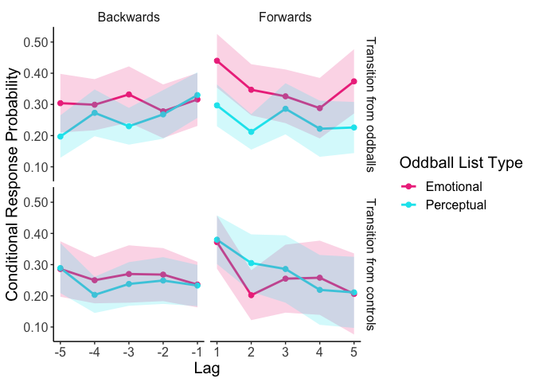

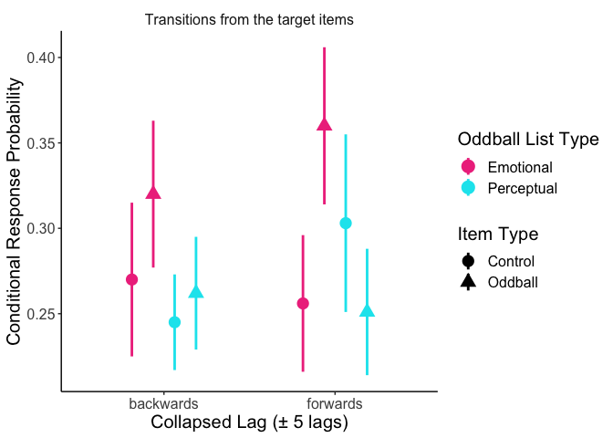

```
## ANOVA Table (type III tests)
##
##                  Effect DFn DFd      F        p p<.05   pes
## 1           oddballtype   1  69  2.675 0.106000       0.037
## 2             item_type   1  69  1.355 0.248000       0.019
## 3 oddballtype:item_type   1  69 12.213 0.000834     * 0.150

## # A tibble: 2 × 11
##   oddballtype .y.     group1  group2     n1    n2 statistic    df     p p.adj
## * <fct>       <chr>   <chr>   <chr>   <int> <int>     <dbl> <dbl> <dbl> <dbl>
## 1 E           CRPmean control oddball    70    70     -3.23    69 0.002 0.002
## 2 P           CRPmean control oddball    70    70      1.73    69 0.088 0.088
## # … with 1 more variable: p.adj.signif <chr>

## # A tibble: 2 × 8
##   .y.     group1  group2  effsize oddballtype    n1    n2 magnitude
## * <chr>   <chr>   <chr>     <dbl> <fct>       <int> <int> <ord>
## 1 CRPmean control oddball  -0.386 E              70    70 small
## 2 CRPmean control oddball   0.207 P              70    70 small

## ANOVA Table (type III tests)
##
##                  Effect DFn DFd     F     p p<.05   pes
## 1           oddballtype   1  69 3.992 0.050     * 0.055
## 2             item_type   1  69 4.646 0.035     * 0.063
## 3 oddballtype:item_type   1  69 0.978 0.326       0.014

## # A tibble: 2 × 11
##   oddballtype .y.     group1  group2     n1    n2 statistic    df     p p.adj
## * <fct>       <chr>   <chr>   <chr>   <int> <int>     <dbl> <dbl> <dbl> <dbl>
## 1 E           CRPmean control oddball    70    70    -1.85     69 0.068 0.068
## 2 P           CRPmean control oddball    70    70    -0.956    69 0.343 0.343
## # … with 1 more variable: p.adj.signif <chr>

## # A tibble: 2 × 8
##   .y.     group1  group2  effsize oddballtype    n1    n2 magnitude
## * <chr>   <chr>   <chr>     <dbl> <fct>       <int> <int> <ord>
## 1 CRPmean control oddball  -0.222 E              70    70 small
## 2 CRPmean control oddball  -0.114 P              70    70 negligible
```

# *Supplementary Material Figures and Analyses*

# Fig. S1A,S1B,S1C,S1D, Table S1- Recall probability

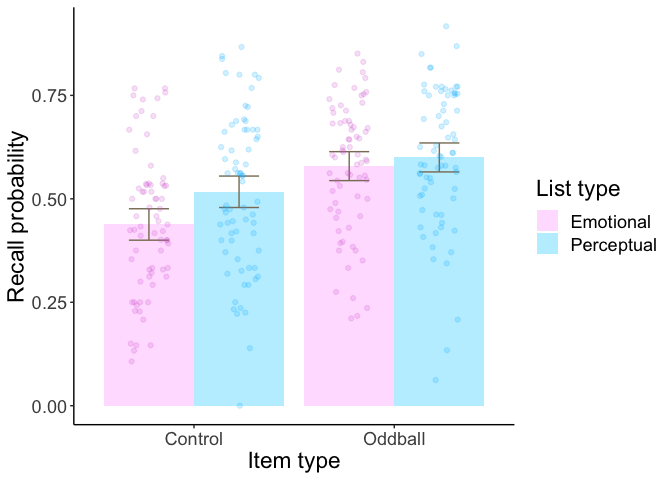

```
## # A tibble: 1 × 4
##     df1   df2 statistic     p
##   <int> <int>     <dbl> <dbl>
## 1     3   276      1.20 0.309

## ANOVA Table (type III tests)
##
##           Effect DFn DFd      F        p p<.05   pes
## 1      list_type   1  69  5.316 2.40e-02     * 0.072
## 2           item   1  69 35.098 1.11e-07     * 0.337
## 3 list_type:item   1  69  2.038 1.58e-01       0.029

## # A tibble: 1 × 10
##   .y.   group1  group2     n1    n2 statistic    df           p   p.adj p.adj.signif
## * <chr> <chr>   <chr>   <int> <int>     <dbl> <dbl>       <dbl>   <dbl> <chr>
## 1 mean  control oddball    70    70     -5.92    69 0.000000112 1.12e-7 ****

## # A tibble: 1 × 7
##   .y.   group1  group2  effsize    n1    n2 magnitude
## * <chr> <chr>   <chr>     <dbl> <int> <int> <ord>
## 1 mean  control oddball  -0.708    70    70 moderate

## # A tibble: 1 × 10
##   .y.   group1    group2        n1    n2 statistic    df     p p.adj p.adj.signif
## * <chr> <chr>     <chr>      <int> <int>     <dbl> <dbl> <dbl> <dbl> <chr>
## 1 mean  emotional perceptual    70    70     -2.30    69 0.024 0.024 *

## # A tibble: 1 × 7
##   .y.   group1    group2     effsize    n1    n2 magnitude
## * <chr> <chr>     <chr>        <dbl> <int> <int> <ord>
## 1 mean  emotional perceptual  -0.275    70    70 small
```

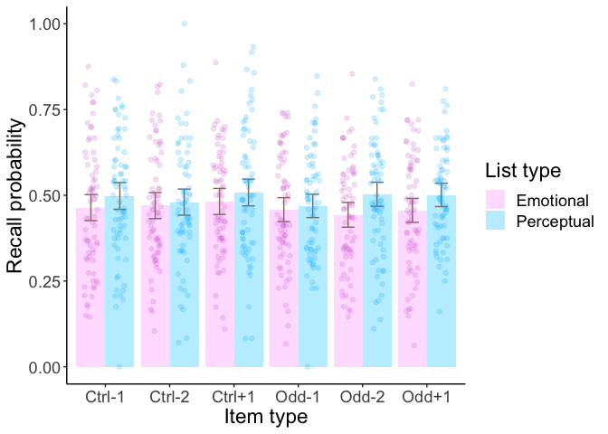

```
## # A tibble: 1 × 4
##     df1   df2 statistic     p
##   <int> <int>     <dbl> <dbl>
## 1    11   828     0.924 0.516

## ANOVA Table (type III tests)
##
##                    Effect DFn DFd     F     p p<.05   pes
## 1               list_type   1  69 7.175 0.009     * 0.094
## 2                oddvctrl   1  69 1.882 0.175       0.027
## 3                    item   2 138 0.943 0.392       0.013
## 4      list_type:oddvctrl   1  69 0.594 0.444       0.009
## 5          list_type:item   2 138 0.255 0.776       0.004
## 6           oddvctrl:item   2 138 0.163 0.849       0.002
## 7 list_type:oddvctrl:item   2 138 0.567 0.569       0.008

## # A tibble: 1 × 10
##   .y.   group1    group2        n1    n2 statistic    df     p p.adj p.adj.signif
## * <chr> <chr>     <chr>      <int> <int>     <dbl> <dbl> <dbl> <dbl> <chr>
## 1 mean  emotional perceptual    70    70     -2.68    69 0.009 0.009 **

## # A tibble: 1 × 7
##   .y.   group1    group2     effsize    n1    n2 magnitude
## * <chr> <chr>     <chr>        <dbl> <int> <int> <ord>
## 1 mean  emotional perceptual  -0.320    70    70 small
```

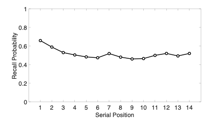

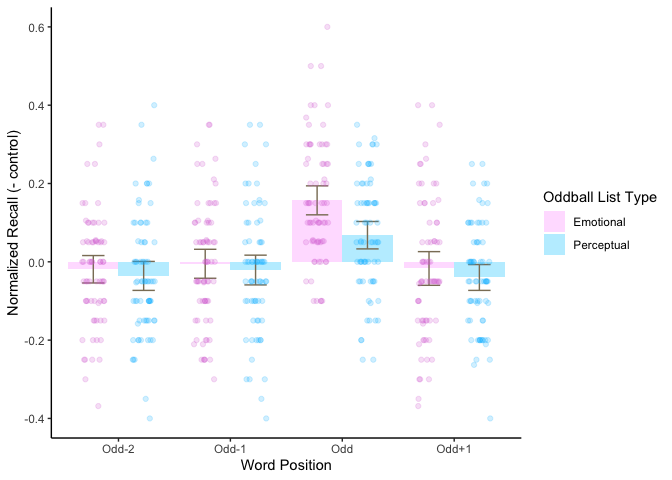

# Fig. S2 Conditional Response Probability Curves by Stimulus Onset Asynchrony

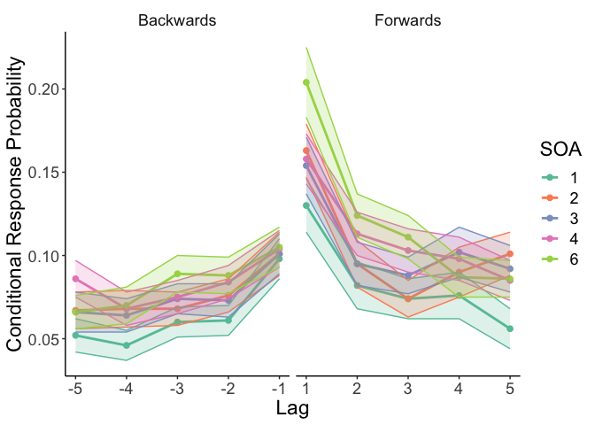

# Fig. S3- Correlation of lag + 1 from emotional oddballs with E-1 recall

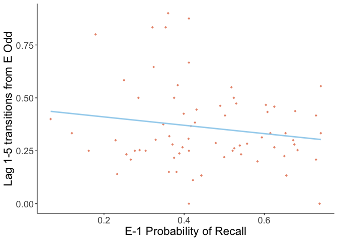

```
##
##  Spearman's rank correlation rho
##
## data:  corrplot$V1 and corrplot$V2
## S = 61954, p-value = 0.4895
## alternative hypothesis: true rho is not equal to 0
## sample estimates:
##         rho
## -0.08396426
```

# Output for JASP in table S3, S4, S5- recall probability by SOA (view code)

# Table S6- Emotional ratings

```
## # A tibble: 1 × 10
##   .y.   group1 group2     n1    n2 statistic    df        p    p.adj p.adj.signif
## * <chr> <chr>  <chr>   <int> <int>     <dbl> <dbl>    <dbl>    <dbl> <chr>
## 1 mean  eodd   neutral    15    15     -19.8    14 1.26e-11 1.26e-11 ****

## # A tibble: 1 × 7
##   .y.   group1 group2  effsize    n1    n2 magnitude
## * <chr> <chr>  <chr>     <dbl> <int> <int> <ord>
## 1 mean  eodd   neutral   -5.11    15    15 large
```

# Table S7- Semantic ratings

```
## ANOVA Table (type III tests)
##
##    Effect DFn DFd      F        p p<.05   pes
## 1 oddtype   1  13 30.125 0.000104     * 0.699

## # A tibble: 1 × 10
##   .y.   group1    group2        n1    n2 statistic    df       p   p.adj p.adj.signif
## * <chr> <chr>     <chr>      <int> <int>     <dbl> <dbl>   <dbl>   <dbl> <chr>
## 1 mean  emotional perceptual    14    14     -5.49    13 1.04e-4 1.04e-4 ***

## # A tibble: 1 × 7
##   .y.   group1    group2     effsize    n1    n2 magnitude
## * <chr> <chr>     <chr>        <dbl> <int> <int> <ord>
## 1 mean  emotional perceptual   -1.47    14    14 large
```